# Select Fiber-seq loci: ALAS1 with and without clustering

Crystal Shan

## Introduction

`selectFiberseqLociWorkflow` is a native R package for analyzing processed Fiber-seq tracks at selected loci. Analysis runs directly in R. Regions use `GRanges`; each locus is a `RangedSummarizedExperiment` with genomic positions in rows and individual reads in columns. This vignette uses the same ALAS1 region and two tutorial LCL samples for both clustering choices.

The bundled data contain up to 100 full-span reads per sample per region, with complete matching m6A, nucleosome, TF-footprint and FIRE records. The small subset has 18 full-span reads at ALAS1 and 16 at PRDX1. It demonstrates usage and numerical consistency; it is not a biological replicate study. The data provenance and reproducible subset-generation script accompany the package. The example files are a subset of the actual AL6 and AL8 LCL tracks.

This tutorial executes all ten public functions. For a categorized guide with short examples, see **Function reference and tutorials** (`vignette("function-reference", package = "selectFiberseqLociWorkflow")`).

| Function | Input | Result or purpose |
| --- | --- | --- |
| `example_data()` | Writable destination | Copies the small LCL dataset; returns paths, samples and regions |
| `make_sample_sheet()` | Sample table or TSV | Validated `DataFrame` of sample paths and explicit formats |
| `prepare_regions()` | Coordinates, `GRanges`, BED, GTF or GFF3 | Named `GRanges` of loci |
| `extract_canonical_tss()` | GTF/GFF3 and selection attribute | Optional stricter `GRanges` of canonical TSSs |
| `validate_inputs()` | Sample sheet and region ranges | Checks files, indexes, contigs and declared track formats |
| `analyze_loci()` | Samples, regions and clustering choice | Named `SimpleList` of locus experiments |
| `locus_profile()` | One locus experiment | Pooled or per-cluster fractions in a `DataFrame` |
| `plot_locus()` | One locus experiment and panel type | Heatmap, ggplot or patchwork composition |
| `cluster_colors()` | Cluster labels or factor levels | Original cluster colors, shared by all plots |
| `write_locus_results()` | One experiment or the results list | RDS objects, TSV tables and PDF panels |

## Load the package and writable example

```r
library(selectFiberseqLociWorkflow)
library(SummarizedExperiment)
library(GenomicRanges)
```

```r
example <- example_data()
samples <- make_sample_sheet(file.path(example$directory, "samples.tsv"))
samples[, c("sample_name", "sample_label", "m6a_format", "tf_format")]
```

```
#> DataFrame with 2 rows and 4 columns
#>        sample_name sample_label       m6a_format         tf_format
#>        <character>  <character>      <character>       <character>
#> 1 AL6_bc2162_19093          AL6 bed12_fibertools bed15_fiberhmm_tf
#> 2 AL8_bc2170_19151          AL8 bed12_fibertools bed15_fiberhmm_tf
```

```r
# regions.tsv has a header and BED (zero-based, half-open) coordinates.
region_table <- read.delim(file.path(example$directory, "regions.tsv"))
regions <- prepare_regions(region_table, coordinate_system = "bed")
alas1 <- regions["ALAS1"]
alas1
```

```
#> GRanges object with 1 range and 2 metadata columns:
#>         seqnames            ranges strand |   region_id       tss
#>            <Rle>         <IRanges>  <Rle> | <character> <numeric>
#>   ALAS1     chr3 52197160-52199159      + |       ALAS1  52198160
#>   -------
#>   seqinfo: 2 sequences from an unspecified genome; no seqlengths
```

```r
validate_inputs(samples, alas1)
```

The input region covers chr3:52197160-52199159, with a TSS at 52198160 (one-based inclusive). File formats are explicit. The package does not infer whether tracks came from fibertools or FiberHMM.

## Analyze without clustering

Choose `clustering` explicitly. Reads are retained only if their longest alignment spans the whole selected window, including reads with no m6A calls. The assay is sparse and binary: zero means no observed m6A call at that base, not a direct measurement that every base is an unmethylated adenine.

```r
unclustered <- analyze_loci(samples, alas1, clustering = FALSE)[["ALAS1"]]
unclustered
```

```
#> class: RangedSummarizedExperiment
#> dim: 2000 18
#> metadata(7): region samples ... empty_footprint_tracks package_version
#> assays(1): m6a
#> rownames(2000): chr3:52197160 chr3:52197161 ... chr3:52199158
#>   chr3:52199159
#> rowData names(0):
#> colnames(18): AL6_bc2162_19093::m84241_250514_222554_s2/132252921/ccs
#>   AL6_bc2162_19093::m84241_250514_222554_s2/265817825/ccs ...
#>   AL8_bc2170_19151::m84241_250325_230544_s1/189993650/ccs
#>   AL8_bc2170_19151::m84241_250325_230544_s1/87559118/ccs
#> colData names(11): RID original_RID ... read_range footprints
```

```r
colData(unclustered)[, c("sample_name", "original_RID", "start", "end")]
```

```
#> DataFrame with 18 rows and 4 columns
#>                                                              sample_name
#>                                                              <character>
#> AL6_bc2162_19093::m84241_250514_222554_s2/132252921/ccs AL6_bc2162_19093
#> AL6_bc2162_19093::m84241_250514_222554_s2/265817825/ccs AL6_bc2162_19093
#> AL6_bc2162_19093::m84241_241120_172940_s3/100664448/ccs AL6_bc2162_19093
#> AL6_bc2162_19093::m84241_250514_222554_s2/166397328/ccs AL6_bc2162_19093
#> AL6_bc2162_19093::m84241_250906_015218_s2/58917335/ccs  AL6_bc2162_19093
#> ...                                                                  ...
#> AL8_bc2170_19151::m84241_241120_172940_s3/42731319/ccs  AL8_bc2170_19151
#> AL8_bc2170_19151::m84241_250325_230544_s1/61407770/ccs  AL8_bc2170_19151
#> AL8_bc2170_19151::m84241_250325_230544_s1/40307897/ccs  AL8_bc2170_19151
#> AL8_bc2170_19151::m84241_250325_230544_s1/189993650/ccs AL8_bc2170_19151
#> AL8_bc2170_19151::m84241_250325_230544_s1/87559118/ccs  AL8_bc2170_19151
#>                                                                   original_RID
#>                                                                    <character>
#> AL6_bc2162_19093::m84241_250514_222554_s2/132252921/ccs m84241_250514_222554..
#> AL6_bc2162_19093::m84241_250514_222554_s2/265817825/ccs m84241_250514_222554..
#> AL6_bc2162_19093::m84241_241120_172940_s3/100664448/ccs m84241_241120_172940..
#> AL6_bc2162_19093::m84241_250514_222554_s2/166397328/ccs m84241_250514_222554..
#> AL6_bc2162_19093::m84241_250906_015218_s2/58917335/ccs  m84241_250906_015218..
#> ...                                                                        ...
#> AL8_bc2170_19151::m84241_241120_172940_s3/42731319/ccs  m84241_241120_172940..
#> AL8_bc2170_19151::m84241_250325_230544_s1/61407770/ccs  m84241_250325_230544..
#> AL8_bc2170_19151::m84241_250325_230544_s1/40307897/ccs  m84241_250325_230544..
#> AL8_bc2170_19151::m84241_250325_230544_s1/189993650/ccs m84241_250325_230544..
#> AL8_bc2170_19151::m84241_250325_230544_s1/87559118/ccs  m84241_250325_230544..
#>                                                             start       end
#>                                                         <integer> <integer>
#> AL6_bc2162_19093::m84241_250514_222554_s2/132252921/ccs  52193358  52207176
#> AL6_bc2162_19093::m84241_250514_222554_s2/265817825/ccs  52193478  52200906
#> AL6_bc2162_19093::m84241_241120_172940_s3/100664448/ccs  52194577  52203172
#> AL6_bc2162_19093::m84241_250514_222554_s2/166397328/ccs  52195513  52208797
#> AL6_bc2162_19093::m84241_250906_015218_s2/58917335/ccs   52196064  52204805
#> ...                                                           ...       ...
#> AL8_bc2170_19151::m84241_241120_172940_s3/42731319/ccs   52193116  52206037
#> AL8_bc2170_19151::m84241_250325_230544_s1/61407770/ccs   52194117  52217369
#> AL8_bc2170_19151::m84241_250325_230544_s1/40307897/ccs   52195127  52205564
#> AL8_bc2170_19151::m84241_250325_230544_s1/189993650/ccs  52195694  52212504
#> AL8_bc2170_19151::m84241_250325_230544_s1/87559118/ccs   52196366  52202979
```

### Interoperability and coordinate consistency

All in-memory coordinates are one-based inclusive. BED starts are converted once at import. `rowRanges` identifies each assay row; `colData` identifies its corresponding read column. Read alignments are `GRanges`, and footprints are grouped by read in a `GRangesList` column of `colData`.

```r
rowRanges(unclustered)[1:3]
```

```
#> GRanges object with 3 ranges and 0 metadata columns:
#>                 seqnames    ranges strand
#>                    <Rle> <IRanges>  <Rle>
#>   chr3:52197160     chr3  52197160      *
#>   chr3:52197161     chr3  52197161      *
#>   chr3:52197162     chr3  52197162      *
#>   -------
#>   seqinfo: 2 sequences from an unspecified genome; no seqlengths
```

```r
colData(unclustered)$read_range[1:3]
```

```
#> GRanges object with 3 ranges and 0 metadata columns:
#>       seqnames            ranges strand
#>          <Rle>         <IRanges>  <Rle>
#>   [1]     chr3 52193358-52207176      +
#>   [2]     chr3 52193478-52200906      +
#>   [3]     chr3 52194577-52203172      -
#>   -------
#>   seqinfo: 2 sequences from an unspecified genome; no seqlengths
```

```r
colData(unclustered)$footprints[1]
```

```
#> GRangesList object of length 1:
#> $`AL6_bc2162_19093::m84241_250514_222554_s2/132252921/ccs`
#> GRanges object with 10 ranges and 3 metadata columns:
#>        seqnames            ranges strand |                    RID       track
#>           <Rle>         <IRanges>  <Rle> |            <character> <character>
#>    [1]     chr3 52197131-52197272      * | AL6_bc2162_19093::m8..  nucleosome
#>    [2]     chr3 52197291-52197426      * | AL6_bc2162_19093::m8..  nucleosome
#>    [3]     chr3 52197638-52197775      * | AL6_bc2162_19093::m8..  nucleosome
#>    [4]     chr3 52197777-52197916      * | AL6_bc2162_19093::m8..  nucleosome
#>    [5]     chr3 52198881-52199026      * | AL6_bc2162_19093::m8..  nucleosome
#>    [6]     chr3 52199096-52199241      * | AL6_bc2162_19093::m8..  nucleosome
#>    [7]     chr3 52197977-52197992      * | AL6_bc2162_19093::m8..          tf
#>    [8]     chr3 52198832-52198851      * | AL6_bc2162_19093::m8..          tf
#>    [9]     chr3 52199055-52199077      * | AL6_bc2162_19093::m8..          tf
#>   [10]     chr3 52197917-52198167      * | AL6_bc2162_19093::m8..        fire
#>                        class
#>                  <character>
#>    [1] 130-160 bp nucleosome
#>    [2] 130-160 bp nucleosome
#>    [3] 130-160 bp nucleosome
#>    [4] 130-160 bp nucleosome
#>    [5] 130-160 bp nucleosome
#>    [6] 130-160 bp nucleosome
#>    [7]             size10-30
#>    [8]             size10-30
#>    [9]             size10-30
#>   [10]                  fire
#>   -------
#>   seqinfo: 2 sequences from an unspecified genome; no seqlengths
```

```r
small <- unclustered[1:20, c(3, 1)]
stopifnot(identical(colnames(small), rownames(colData(small))),
    identical(colnames(small), colData(small)$RID),
    identical(names(rowRanges(small)), rownames(small)))
small
```

```
#> class: RangedSummarizedExperiment
#> dim: 20 2
#> metadata(7): region samples ... empty_footprint_tracks package_version
#> assays(1): m6a
#> rownames(20): chr3:52197160 chr3:52197161 ... chr3:52197178
#>   chr3:52197179
#> rowData names(0):
#> colnames(2): AL6_bc2162_19093::m84241_241120_172940_s3/100664448/ccs
#>   AL6_bc2162_19093::m84241_250514_222554_s2/132252921/ccs
#> colData names(11): RID original_RID ... read_range footprints
```

Subsetting keeps read metadata, alignment ranges and footprints aligned with assay columns. Footprints describe the retained read within the original locus; row subsetting does not clip these stored intervals. Original QC, parameters and the cluster graph remain in `metadata` as run provenance. `locus_profile()` recalculates fractions for the current columns.

### Unclustered views

Rows in the heatmap follow sample-sheet order, alignment start and read ID. The heatmap displays reads vertically and positions horizontally even though the underlying experiment uses the standard features-by-observations layout. The sample strip is farthest left; clustered views place the cluster strip next to it. Coordinate ticks and the orange dashed TSS marker follow the original plotting tutorial. Sample colors follow the sample sheet consistently across all read panels.

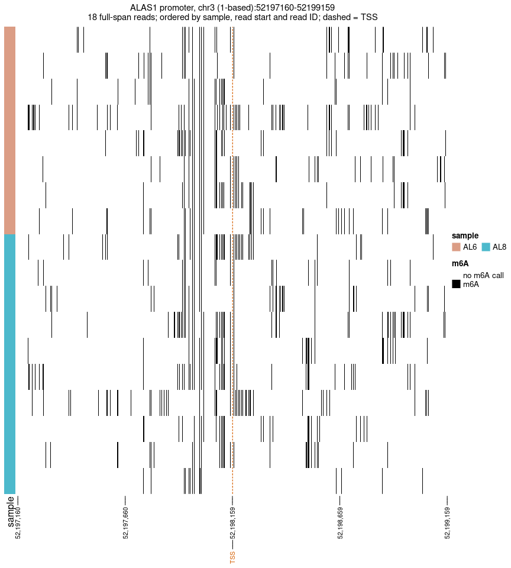

```r
ComplexHeatmap::draw(plot_locus(unclustered, "heatmap"))
```

The pooled fraction divides by all full-span reads, including zero-call reads. Grey shows observed-position fractions; the blue curve uses the tutorial 10-bp sliding-window mean. The dashed line marks the supplied TSS.

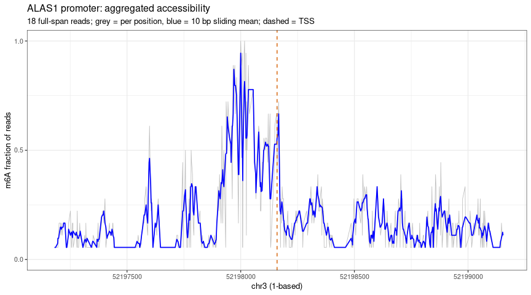

```r
plot_locus(unclustered, "profile")
```

```r
head(locus_profile(unclustered))
```

```
#> DataFrame with 6 rows and 8 columns
#>         pos        base       group       cov       met      frac smooth_cov
#>   <integer> <character> <character> <integer> <numeric> <numeric>  <integer>
#> 1  52197181           A         All        18         1 0.0555556         18
#> 2  52197186           A         All        18         1 0.0555556         18
#> 3  52197195           A         All        18         1 0.0555556         18
#> 4  52197196           A         All        18         1 0.0555556         18
#> 5  52197199           A         All        18         2 0.1111111         18
#> 6  52197201           A         All        18         3 0.1666667         18
#>   smooth_frac
#>     <numeric>
#> 1   0.0555556
#> 2   0.0555556
#> 3   0.0740741
#> 4   0.0972222
#> 5   0.0972222
#> 6   0.1111111
```

By default, optional tracks use nucleosomes of 130-160 bp and TF footprints in [10,30), [40,60), or [60,80) bp. FiberHMM TF blocks require a score of at least 50. The footprint figure stacks the accessibility profile, blue m6A reads, and overlaid FIRE/nucleosome/TF tracks, with relative panel heights 2:6:6. FIRE is orange, nucleosomes are dark blue, and the three TF size classes are purple, magenta and cyan. Both read panels include the same sample-first annotations and read order as the heatmap.

TF length classes can be changed with `analyze_loci(tf_length_ranges = list(c(30, 39), c(80, 120)), ...)`, using inclusive bounds. Use `tf_length_ranges = NULL` to retain all positive lengths. This applies to both FiberHMM BED15 and custom BED6 TF inputs.

A supplied footprint track with no retained calls raises the warning `no footprints called in the selected region`; the analysis still completes.

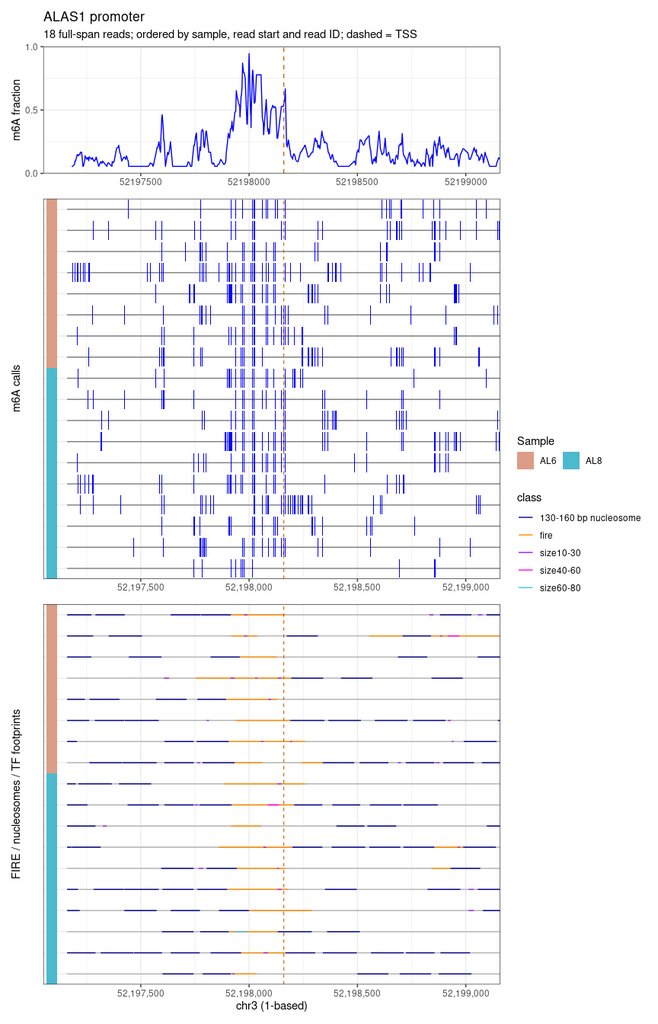

```r
plot_locus(unclustered, "footprints")
```

## Analyze the same locus with clustering

Clustering uses observed m6A positions, Manhattan distances, a nearest-neighbor graph and Leiden communities. It does not change the input read set, sparse assay, pooled denominators or unclustered plots. The seed and all parameters are saved with the experiment. Exact pairwise distances require memory quadratic in the number of reads, so select suitably sized loci and datasets.

```r
clustered <- analyze_loci(samples, alas1, clustering = TRUE,
    window_size = 0, k_neighbors = 10, resolution = 1, seed = 1)[["ALAS1"]]
stopifnot(identical(assay(unclustered), assay(clustered)),
    identical(colnames(unclustered), colnames(clustered)),
    identical(locus_profile(unclustered), locus_profile(clustered)))
table(colData(clustered)$sample_label, colData(clustered)$cluster)
```

```
#>
#>       cluster1 cluster2
#>   AL6        5        3
#>   AL8        4        6
```

```r
metadata(clustered)$clustering_status
```

```
#> [1] "complete"
```

Cluster colors match the original Leiden plotting functions. Numeric IDs keep their colors when a cluster is absent from a subset. For custom figures, use the same palette (keep the complete factor levels for more than 25 clusters):

```r
cluster_colors(colData(clustered)$cluster)
```

```
#>      cluster1      cluster2
#> "dodgerblue2"     "#E31A1C"
```

```r
cluster_colors(c("cluster3", "cluster1"))
```

```
#>      cluster3      cluster1
#>      "green4" "dodgerblue2"
```

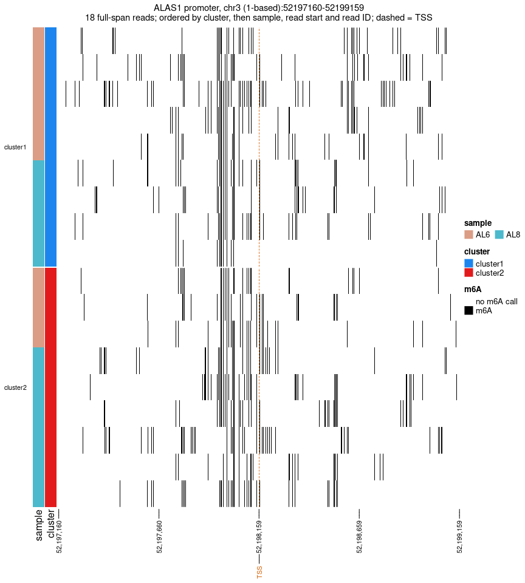

```r
ComplexHeatmap::draw(plot_locus(clustered, "heatmap", clustered = TRUE))
```

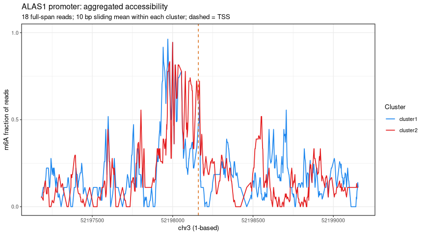

```r
plot_locus(clustered, "profile", clustered = TRUE)
```

```r
head(locus_profile(clustered, by_cluster = TRUE))
```

```
#> DataFrame with 6 rows and 8 columns
#>         pos        base       group       cov       met      frac smooth_cov
#>   <integer> <character> <character> <integer> <numeric> <numeric>  <integer>
#> 1  52197181           A    cluster1         9         0  0.000000          9
#> 2  52197186           A    cluster1         9         1  0.111111          9
#> 3  52197195           A    cluster1         9         1  0.111111          9
#> 4  52197196           A    cluster1         9         1  0.111111          9
#> 5  52197199           A    cluster1         9         1  0.111111          9
#> 6  52197201           A    cluster1         9         1  0.111111          9
#>   smooth_frac
#>     <numeric>
#> 1   0.0555556
#> 2   0.0555556
#> 3   0.1111111
#> 4   0.1111111
#> 5   0.1111111
#> 6   0.1111111
```

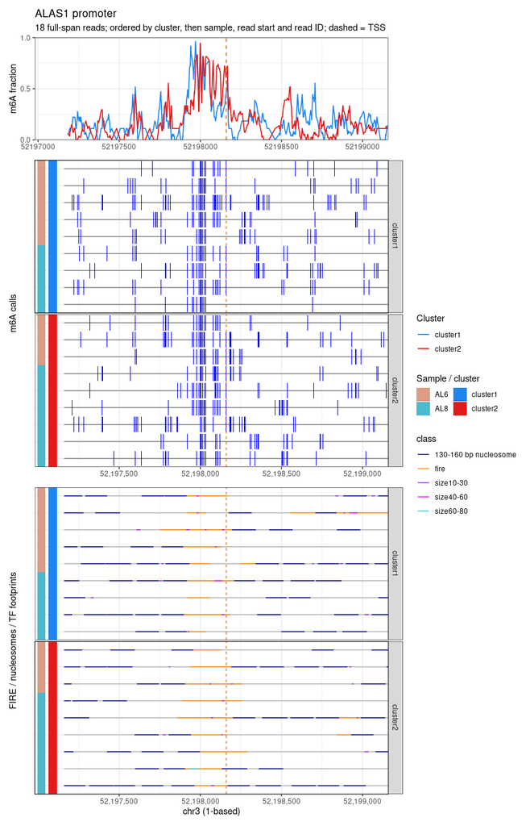

```r
plot_locus(clustered, "footprints", clustered = TRUE)
```

Cluster plots only reorder reads or split profile denominators by existing cluster assignments. If a locus has fewer than three reads or two occupied features, clustering is skipped with a reason in `metadata`.

### Choose bin size, nearest neighbors and resolution

These are arguments to `analyze_loci()`; edit their values when starting an analysis. The current defaults are unchanged:

| Argument | Default | Meaning |
| --- | --- | --- |
| `window_size` | `0` | No binning; cluster using individual observed m6A sites. A positive integer uses that bin width in bp. |
| `k_neighbors` | `10` | Number of Manhattan nearest neighbors per read, capped at the number of reads minus one. |
| `resolution` | `1` | Nonnegative Leiden resolution; larger values generally favor finer partitions. |
| `seed` | `1` | Reproducible random seed for Leiden clustering. |

With binning, windows start at the selected locus’s first base. A read’s feature is its mean call across sites observed in any retained read within that bin. Empty bins do not contribute clustering features. The underlying assay and heatmap stay at single-base resolution. `smoothing_bp = 10` is a separate setting for the profile curve, not the clustering bin width.

For example, use 50-bp bins, five neighbors and resolution 0.5. These values are illustrative settings for the small dataset, not optimized parameters.

```r
custom <- analyze_loci(samples, alas1, clustering = TRUE,
    window_size = 50, k_neighbors = 5, resolution = 0.5,
    seed = 1)[["ALAS1"]]
metadata(custom)$parameters[c("window_size", "k_neighbors", "resolution")]
```

```
#> $window_size
#> [1] 50
#>
#> $k_neighbors
#> [1] 5
#>
#> $resolution
#> [1] 0.5
```

```r
metadata(custom)$clustering$params$k_eff
```

```
#> [1] 5
```

```r
table(colData(custom)$sample_label, colData(custom)$cluster)
```

```
#>
#>       cluster1
#>   AL6        8
#>   AL8       10
```

```r
# Binning and clustering parameters do not change the stored m6A assay
# or the pooled profile and its full-span-read denominator.
stopifnot(identical(assay(unclustered), assay(custom)),
    identical(locus_profile(unclustered), locus_profile(custom)))
```

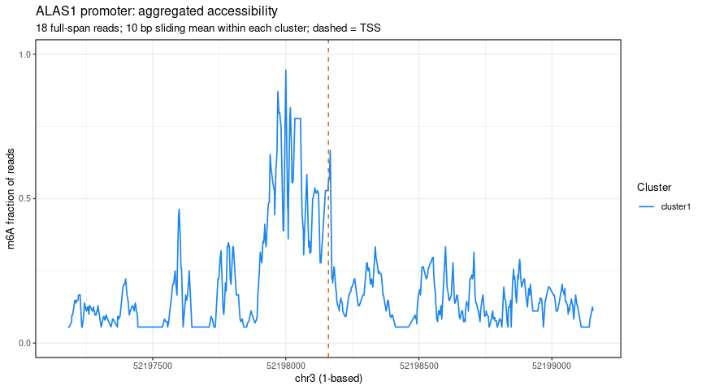

```r
plot_locus(custom, "profile", clustered = TRUE)
```

For `clustering = FALSE`, `window_size`, `k_neighbors` and `resolution` do not affect the analysis. To change a fitted partition, call `analyze_loci()` again with the desired settings; `plot_locus()` displays an existing result.

## Export and reload

Save both runs to separate, new directories under one output folder. The run without clustering writes only `unclustered/` panels. The run with clustering writes both `unclustered/` and `clustered/` panels alongside the complete Bioconductor object. The `unclustered` views remain independent of clustering parameters. RDS files preserve the choice and parameters for later plotting.

```r
output <- tempfile("alas1-output-")
write_locus_results(unclustered, file.path(output, "without-clustering"))
write_locus_results(clustered, file.path(output, "with-clustering"))
list.files(output, recursive = TRUE)
```

```
#>  [1] "with-clustering/ALAS1/clustered/accessibility_profile.tsv"
#>  [2] "with-clustering/ALAS1/clustered/aggregate_m6a_profile.pdf"
#>  [3] "with-clustering/ALAS1/clustered/assignments.tsv"
#>  [4] "with-clustering/ALAS1/clustered/edges.tsv"
#>  [5] "with-clustering/ALAS1/clustered/footprint_tracks.pdf"
#>  [6] "with-clustering/ALAS1/clustered/m6a_heatmap.pdf"
#>  [7] "with-clustering/ALAS1/clustered/manifest.tsv"
#>  [8] "with-clustering/ALAS1/clustered/read_order.tsv"
#>  [9] "with-clustering/ALAS1/locus.rds"
#> [10] "with-clustering/ALAS1/m6a_matrix.rds"
#> [11] "with-clustering/ALAS1/qc.tsv"
#> [12] "with-clustering/ALAS1/reads.tsv"
#> [13] "with-clustering/ALAS1/region.tsv"
#> [14] "with-clustering/ALAS1/unclustered/accessibility_profile.tsv"
#> [15] "with-clustering/ALAS1/unclustered/aggregate_m6a_profile.pdf"
#> [16] "with-clustering/ALAS1/unclustered/footprint_tracks.pdf"
#> [17] "with-clustering/ALAS1/unclustered/m6a_heatmap.pdf"
#> [18] "with-clustering/ALAS1/unclustered/manifest.tsv"
#> [19] "with-clustering/ALAS1/unclustered/read_order.tsv"
#> [20] "without-clustering/ALAS1/locus.rds"
#> [21] "without-clustering/ALAS1/m6a_matrix.rds"
#> [22] "without-clustering/ALAS1/qc.tsv"
#> [23] "without-clustering/ALAS1/reads.tsv"
#> [24] "without-clustering/ALAS1/region.tsv"
#> [25] "without-clustering/ALAS1/unclustered/accessibility_profile.tsv"
#> [26] "without-clustering/ALAS1/unclustered/aggregate_m6a_profile.pdf"
#> [27] "without-clustering/ALAS1/unclustered/footprint_tracks.pdf"
#> [28] "without-clustering/ALAS1/unclustered/m6a_heatmap.pdf"
#> [29] "without-clustering/ALAS1/unclustered/manifest.tsv"
#> [30] "without-clustering/ALAS1/unclustered/read_order.tsv"
```

```r
restored <- readRDS(file.path(output, "with-clustering", "ALAS1", "locus.rds"))
stopifnot(identical(assay(restored), assay(clustered)),
    identical(colData(restored), colData(clustered)),
    identical(rowRanges(restored), rowRanges(clustered)))
```

Within each `ALAS1/` directory, `locus.rds` is the complete experiment; `m6a_matrix.rds` contains only the sparse assay; `reads.tsv`, `qc.tsv` and `region.tsv` describe the reads and input region. Each view contains `m6a_heatmap.pdf`, `aggregate_m6a_profile.pdf`, `footprint_tracks.pdf`, `accessibility_profile.tsv`, `read_order.tsv` and `manifest.tsv`. The clustered view also contains `assignments.tsv` and `edges.tsv`. For persistent results, replace `tempfile()` with your own output directory.

## User data and plant annotations

Create a sample sheet with `make_sample_sheet(data.frame(...))`. Required columns are `sample_name`, `m6a` and `m6a_format`; optional tracks have their own explicit format columns. Paths can use `{sample_name}` and `{chr}` templates. Use bgzip-compressed tracks with adjacent tabix indexes and exact matching contig names from the same genome assembly. The package expects processed tracks; it does not call fibertools or FiberHMM itself.

`prepare_regions()` accepts `GRanges`, BED files, one-based inclusive coordinate strings, coordinate tables with declared conventions, or GTF/GFF3 transcript annotations. Ordinary annotation extraction retains distinct TSSs and does not require canonical transcripts. Promoter flanks default to 1,000 bp.

```r
annotation <- system.file("extdata", "plant", "annotation.gff3",
    package = "selectFiberseqLociWorkflow")
plant_regions <- prepare_regions(annotation = annotation)
plant_regions
```

```
#> GRanges object with 3 ranges and 5 metadata columns:
#>                                    seqnames    ranges strand |
#>                                       <Rle> <IRanges>  <Rle> |
#>           AT5G00010_Chr5_2001_+        Chr5 1001-3000      + |
#>           AT5G00010_Chr5_2201_+        Chr5 1201-3200      + |
#>   PlantGene2_scaffold_42_5000_- scaffold_42 4000-5999      - |
#>                                              region_id       tss     gene_id
#>                                            <character> <numeric> <character>
#>           AT5G00010_Chr5_2001_+  AT5G00010_Chr5_2001_+      2001   AT5G00010
#>           AT5G00010_Chr5_2201_+  AT5G00010_Chr5_2201_+      2201   AT5G00010
#>   PlantGene2_scaffold_42_5000_- PlantGene2_scaffold_..      5000  PlantGene2
#>                                   gene_name         transcript_ids
#>                                 <character>            <character>
#>           AT5G00010_Chr5_2001_+   PlantGene AT5G00010.1,AT5G0001..
#>           AT5G00010_Chr5_2201_+   PlantGene            AT5G00010.2
#>   PlantGene2_scaffold_42_5000_-          NA           PlantGene2.1
#>   -------
#>   seqinfo: 2 sequences from an unspecified genome; no seqlengths
```

```r
prepare_regions("scaffold_42:4001-6000")
```

```
#> GRanges object with 1 range and 2 metadata columns:
#>                            seqnames    ranges strand |             region_id
#>                               <Rle> <IRanges>  <Rle> |           <character>
#>   scaffold_42_4000_6000 scaffold_42 4001-6000      * | scaffold_42_4000_6000
#>                               tss
#>                         <numeric>
#>   scaffold_42_4000_6000        NA
#>   -------
#>   seqinfo: 1 sequence from an unspecified genome; no seqlengths
```

```r
extract_canonical_tss(annotation, genes = "AT5G00010",
    attribute = "canonical", value = "true")
```

```
#> GRanges object with 1 range and 5 metadata columns:
#>                         seqnames    ranges strand |             region_id
#>                            <Rle> <IRanges>  <Rle> |           <character>
#>   AT5G00010_Chr5_2001_+     Chr5      2001      + | AT5G00010_Chr5_2001_+
#>                               tss     gene_id   gene_name transcript_ids
#>                         <numeric> <character> <character>    <character>
#>   AT5G00010_Chr5_2001_+      2001   AT5G00010   PlantGene    AT5G00010.1
#>   -------
#>   seqinfo: 1 sequence from an unspecified genome; no seqlengths
```

The synthetic fixture includes `Chr5`, `scaffold_42`, both strands, shared and distinct transcript TSSs, and genes without canonical tags. It verifies format and coordinate compatibility with plants; it does not validate a particular plant caller or assembly. `extract_canonical_tss()` is an optional stricter helper and reports genes with missing or ambiguous selections.